# Lab 5

Tianhao Jiang

## Higgs Classification

In this project we are going to look at an inclusive search for the standard model Higgs boson in pp collisions at √ s = 13 TeV at the LHC using simulated data [A. Schuy]. The Higgs bosons are produced with large transverse momentum (pT) and decaying to a bottom quark-antiquark pair. The Higgs candidates could be reconstructed as large-radius jets using Calorimeters. Due to large QCD backgorund containmination, the direct 5-sigma observation of this Higgs channel is not accomplished yet[Phys. Rev. Lett. 120, 071802 (2018)]. We are going to use a set of training datasets to optimize event selections in order to enhance the discovery sensitivity. The optimal event selections will be applied to a selected pseudo-experiment data.

Lab 5a. Download the training datasets from one of the two pT-range folders. In each folder, there are 2 files, each containing 100k jets. The signal dataset is labeled as “higgs” and the background dataset is labeled as “qcd.”

I chose the high-pT samples.

```python
# import libraries
import pickle
import numpy as np
import matplotlib
import matplotlib.pyplot as plt
import scipy
import math
from scipy import stats
from scipy import signal
from math import floor
#this sets the size of the plot to something useful
plt.rcParams["figure.figsize"] = (20,15)
```

```python
# open the file of interest, and use pickle loading
infile = open ("Sample_pt_1000_1200/qcd_100000_pt_1000_1200.pkl",'rb')
qcd = pickle.load(infile)
infile = open ("Sample_pt_1000_1200/higgs_100000_pt_1000_1200.pkl",'rb')
higgs = pickle.load(infile)

# list all keys of the files
print(qcd.keys())
print(higgs.keys())
```

```
Index(['pt', 'eta', 'phi', 'mass', 'ee2', 'ee3', 'd2', 'angularity', 't1',
       't2', 't3', 't21', 't32', 'KtDeltaR'],
      dtype='object')
Index(['pt', 'eta', 'phi', 'mass', 'ee2', 'ee3', 'd2', 'angularity', 't1',
       't2', 't3', 't21', 't32', 'KtDeltaR'],
      dtype='object')
```

The data has 14 variables which describe the properties of jets. eta and phi describes the orientation of the jet as specified in https://arxiv.org/pdf/1709.04533.pdf, Figure 3. pt and mass are the transverse momentum and mass of the jet in GeV. The other variables are given in https://arxiv.org/abs/1201.0008, Table 1. ee2 and ee3 are ratios of Energy Correlation Functions. d2 = ee3/ee2^3 is used to identify two body stuctures in jet. t1, t2, and t3 are the 1, 2, and 3-subjettiness. t21 = t2/t1 and t32 = t3/t2 are used to identify 2 and 3-body structures within jets, respectively. The smaller d2, t21 or t32 is, the more likely the jet is to have a 2 or 3-body substructure.

Below I plotted histograms of both signals (higgs) and the background (qcd) for each of the 14 variables to see if the variables provide discrimination power between the signal and the background.

```python
def compare(param, ax, sigmas = 4, num_bins = 500):
    left1 = np.min([np.min(qcd[param]),np.min(higgs[param])])
    left2 = np.min([np.mean(qcd[param])-sigmas*np.std(qcd[param]), np.mean(higgs[param])-sigmas*np.std(higgs[param])])
    left = np.max([left1,left2])
    right1 = np.max([np.max(qcd[param]),np.max(higgs[param])])
    right2 = np.max([np.mean(qcd[param])+sigmas*np.std(qcd[param]), np.mean(higgs[param])+sigmas*np.std(higgs[param])])
    bins = np.linspace(np.max([left1,left2]),np.min([right1,right2]),num_bins)
    bins2 = np.linspace(np.max([left1,left2]),np.min([right1,right2]),num_bins)

    ax.hist(qcd[param], bins=bins2, alpha = 0.5, color= 'b',label = 'Background', ls='dashed')
    ax.hist(higgs[param], bins=bins, alpha = 0.5,color= 'r',label = 'Signal')
    ax.legend(prop={'size': 10})
    ax.set_ylabel("Counts")
    ax.set_xlabel(param)
    ax.set_title('Histograms of %s' % param)
```

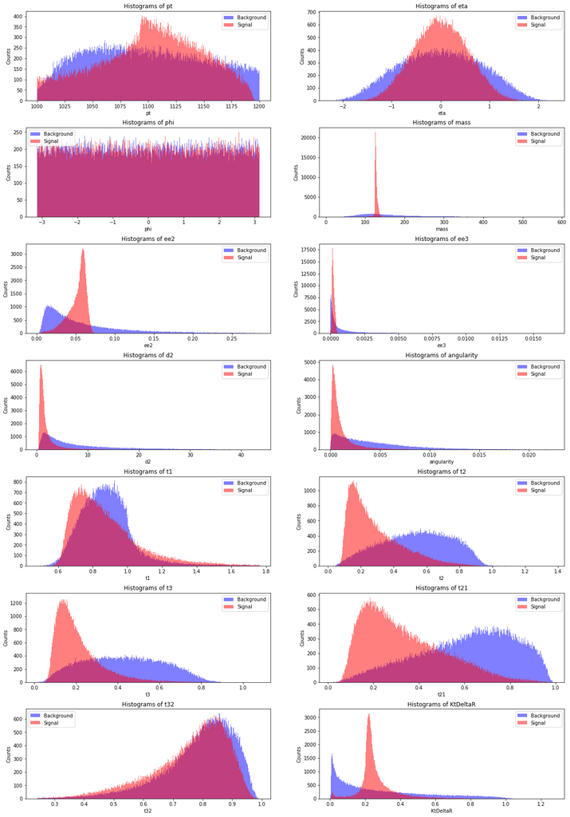

```python
fig, ax = plt.subplots(7, 2, figsize=(20,30))
plt.subplots_adjust(left=None, bottom=None, right=None, top=None, wspace=None, hspace=.3)
i = 0
for param in higgs.keys():
    compare(param, ax[int(i/2),i%2])
    i = i+1
plt.show()
```

As shown, the phi histograms for the background and the signal look the same. And the t32 histograms also look similar. The histograms between background and signal for the other parameters seem to have significant differences. Thus I think all parameters except phi and t32 provide some discrimination power between signal and background.

```python
result = np.array([[0.]*14]*14)
a = np.array([0,1,2,3,6,7,11,12,13])
#a = np.array([0,1,2,3,4,5,6,7,8,9,10,11,12,13])
print("Signal:")
for i1 in range(0,len(a)):
    for j1 in range(i1+1,len(a)):
        i = a[i1]
        j = a[j1]
        #print(i,j)
        v1 = higgs.keys()[i]
        v2 = higgs.keys()[j]
        result[i,j],_ = scipy.stats.pearsonr(higgs[v1], higgs[v2])
        if (abs(result[i,j]) > 0.3):
            print("%s~%s:    %.2f" % (v1, v2, result[i,j]))
float_formatter = "{:.1f}".format
#np.set_printoptions(formatter={'float_kind':float_formatter})
#print(result)
print('\nBackground:')
result = np.array([[0.]*14]*14)
a = np.array([0,1,2,3,6,7,11,12,13])

for i1 in range(0,len(a)):
    for j1 in range(i1+1,len(a)):
        i = a[i1]
        j = a[j1]
        #print(i,j)
        v1 = higgs.keys()[i]
        v2 = higgs.keys()[j]
        result[i,j],_ = scipy.stats.pearsonr(qcd[v1], qcd[v2])
        if (abs(result[i,j]) > 0.3):
            print("%s~%s:    %.2f" % (v1, v2, result[i,j]))
```

```
Signal:
mass~d2:    -0.66
mass~t21:    -0.35
d2~angularity:    0.55
d2~t21:    0.62
angularity~t21:    0.43
t21~t32:    -0.35

Background:
mass~d2:    -0.54
mass~angularity:    0.53
mass~t21:    -0.59
mass~t32:    -0.46
mass~KtDeltaR:    0.71
d2~t21:    0.62
d2~t32:    0.33
d2~KtDeltaR:    -0.39
angularity~KtDeltaR:    0.41
t21~KtDeltaR:    -0.57
```

In both the signal and the background datasets, the pairs formed by mass, d2, and t21 have rather high absolute r values, with mass corrolated d2 and t21 negatively and d2 corrolated to t21 positively. This makes sense since a larger mass should correspond to a higher probability that the jet has multiple sub-jets.

Note that mass vs KtDeltaR has a high r value within the background dataset. The reason behind this may be worth exploring.

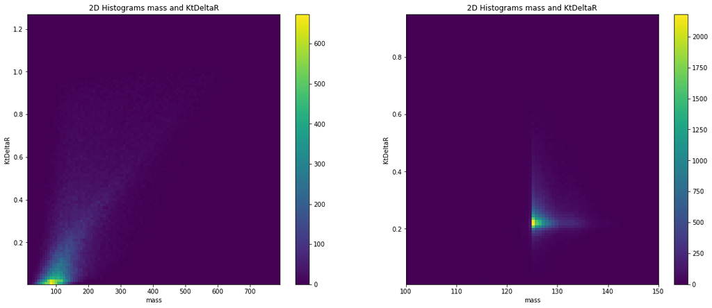

```python
fig, ax = plt.subplots(1,2, figsize=(20,8))
h1 = ax[0].hist2d(qcd['mass'],qcd['KtDeltaR'],bins=[100,100])
#ax[0].set_ylim(0,10)
h2 = ax[1].hist2d(higgs['mass'],higgs['KtDeltaR'],bins=[200,100])
ax[1].set_xlim(100,150)
ax[0].set_ylabel("KtDeltaR")
ax[0].set_xlabel("mass")
ax[0].set_title('2D Histograms mass and KtDeltaR')
fig.colorbar(h1[3],ax = ax[0])
ax[1].set_ylabel("KtDeltaR")
ax[1].set_xlabel("mass")
ax[1].set_title('2D Histograms mass and KtDeltaR')
fig.colorbar(h2[3],ax = ax[1])
plt.show()
```

I don't quite understand what it means by computing expected discovery sensitivity and optimizing the discovery sensitivity by applying selections to features.

Is it related to the significance of discovery? Is it asking me to determine some cuts?